# Project 7: Data Exploration and Visualization

### Overview

In this project, you will apply data exploration and visualization techniques to a real-world dataset of your choice. You'll practice using pandas for data analysis and create meaningful visualizations to gain insights from your data. This project builds on your Python programming skills while introducing you to the exciting world of data science.

In [Lab7](https://colab.research.google.com/drive/15QvSh0csZaCU-OuuPIfpWx5wLDDjmqK4?usp=sharing), you explore the titanic dataset and you should use it as a sample and pick a dataset of your interest to do a similar data exploration and visualization.

### Project Objectives

- Find and select a dataset from a real-world data source
- Formulate a clear inquiry question based on your chosen dataset
- Perform exploratory data analysis using pandas functions
- Create at least two meaningful data visualizations
- Analyze your findings and answer your inquiry question
- Reflect on the insights gained through data exploration

### Data Sources

You can choose from various online data sources such as:

- [Kaggle](https://www.kaggle.com/datasets) - Wide variety of datasets
- [data.gov](https://www.data.gov/) - U.S. government data
- [Our World in Data](https://ourworldindata.org/) - Global development data
- [GitHub](https://github.com/datasets) - Curated datasets
- [Google Dataset Search](https://datasetsearch.research.google.com/) - Search for datasets
- Or any other reliable data source you find interesting

## Part 1: Dataset Selection and Initial Exploration

#### TODO Tasks:

1. Select Your Dataset: Choose a dataset that interests you. Make sure it has at least 100 rows and multiple columns with different data types (e.g., numerical, categorical, dates).

Please create either text or code cells in between the TODO tasks to do the work.

2. Import Libraries: Import the necessary libraries (pandas, matplotlib, seaborn) at the beginning of your notebook by creating code cells below this text cell.

```python
# prompt: import pandas

import pandas as pd
import matplotlib.pyplot as plt
import seaborn as sns
```

3. Load Your Data: Load your chosen dataset using pandas and save it to a pandas dataframe. Please create a code cell below this text cell to do it.

```python
# prompt: import this data from this URL https://drive.google.com/file/d/1iaNm3O3qTn-ihm6sYQSI09ZKJKrXIsrK/view?usp=sharing into pandas dataframe

import pandas as pd
!pip install -U -q PyDrive
from pydrive.auth import GoogleAuth
from pydrive.drive import GoogleDrive
from google.colab import auth
from oauth2client.client import GoogleCredentials

auth.authenticate_user()
gauth = GoogleAuth()
gauth.credentials = GoogleCredentials.get_application_default()
drive = GoogleDrive(gauth)

downloaded = drive.CreateFile({'id':'1iaNm3O3qTn-ihm6sYQSI09ZKJKrXIsrK'})
downloaded.GetContentFile('world_happiness_report_2024.csv')

df = pd.read_csv('world_happiness_report_2024.csv')
print(df.head())
```

```
WARNING:root:pydrive is deprecated and no longer maintained. We recommend that you migrate your projects to pydrive2, the maintained fork of pydrive
```

```
   VIN (1-10)    County      City State  Postal Code  Model Year   Make  \
0  5YJ3E1EB6K      King   Seattle    WA      98178.0        2019  TESLA
1  5YJYGAEE5M    Yakima     Selah    WA      98942.0        2021  TESLA
2  5YJSA1E65N    Yakima   Granger    WA      98932.0        2022  TESLA
3  5YJ3E1EBXN      King  Bellevue    WA      98004.0        2022  TESLA
4  JM3KKEHA8S  Thurston      Yelm    WA      98597.0        2025  MAZDA

     Model                   Electric Vehicle Type  \
0  MODEL 3          Battery Electric Vehicle (BEV)
1  MODEL Y          Battery Electric Vehicle (BEV)
2  MODEL S          Battery Electric Vehicle (BEV)
3  MODEL 3          Battery Electric Vehicle (BEV)
4    CX-90  Plug-in Hybrid Electric Vehicle (PHEV)

   Clean Alternative Fuel Vehicle (CAFV) Eligibility  Electric Range  \
```

[output cut: 26 more lines]

4. Data Summary: Use the following functions to do inital exploration your dataset:
- info() - Display information about the dataset structure
- describe() - Show statistical summary of numerical columns
- head() - Display the first 5 rows (df.head())
- shape - Show the dimensions of the dataset (e.g. df.shape)
- columns - Get the column names (e.g. df.columns)

You may use 5 code cells below this text cell to accomplish it.

```python
# prompt: analyze the data using the info() function

df.info()
```

```
<class 'pandas.core.frame.DataFrame'>
RangeIndex: 246137 entries, 0 to 246136
Data columns (total 17 columns):
 #   Column                                             Non-Null Count   Dtype
---  ------                                             --------------   -----
 0   VIN (1-10)                                         246137 non-null  object
 1   County                                             246133 non-null  object
 2   City                                               246133 non-null  object
 3   State                                              246137 non-null  object
 4   Postal Code                                        246133 non-null  float64
 5   Model Year                                         246137 non-null  int64
 6   Make                                               246137 non-null  object
 7   Model                                              246137 non-null  object
 8   Electric Vehicle Type                              246137 non-null  object
 9   Clean Alternative Fuel Vehicle (CAFV) Eligibility  246137 non-null  object
 10  Electric Range                                     246120 non-null  float64
 11  Base MSRP                                          246120 non-null  float64
 12  Legislative District                               245597 non-null  float64
 13  DOL Vehicle ID                                     246137 non-null  int64
 14  Vehicle Location                                   246126 non-null  object
 15  Electric Utility                                   246133 non-null  object
 16  2020 Census Tract                                  246133 non-null  float64
dtypes: float64(5), int64(2), object(10)
memory usage: 31.9+ MB
```

```python
# prompt: analyze the data using the describe() function

df.describe()
```

|  | Postal Code | Model Year | Electric Range | Base MSRP | Legislative District | DOL Vehicle ID | 2020 Census Tract |
| --- | --- | --- | --- | --- | --- | --- | --- |
| count | 246133.000000 | 246137.000000 | 246120.000000 | 246120.000000 | 245597.000000 | 2.461370e+05 | 2.461330e+05 |
| mean | 98179.658481 | 2021.535698 | 44.872192 | 746.606188 | 28.871831 | 2.374324e+08 | 5.297685e+10 |
| std | 2494.101983 | 2.999144 | 82.913952 | 6987.233456 | 14.895938 | 6.719158e+07 | 1.580103e+09 |
| min | 1731.000000 | 2000.000000 | 0.000000 | 0.000000 | 1.000000 | 4.385000e+03 | 1.001020e+09 |
| 25% | 98052.000000 | 2020.000000 | 0.000000 | 0.000000 | 17.000000 | 2.083391e+08 | 5.303301e+10 |
| 50% | 98126.000000 | 2023.000000 | 0.000000 | 0.000000 | 32.000000 | 2.548460e+08 | 5.303303e+10 |
| 75% | 98375.000000 | 2024.000000 | 37.000000 | 0.000000 | 42.000000 | 2.717319e+08 | 5.305307e+10 |
| max | 99577.000000 | 2026.000000 | 337.000000 | 845000.000000 | 49.000000 | 4.792548e+08 | 5.602100e+10 |

The code above is used to provide the important descriptive values like mean and quartiles to help summarize the data quantitatively.

```python
# prompt: analyze the data using the head() function

print(df.shape)

df.columns
```

```
(246137, 17)
```

```
Index(['VIN (1-10)', 'County', 'City', 'State', 'Postal Code', 'Model Year',
       'Make', 'Model', 'Electric Vehicle Type',
       'Clean Alternative Fuel Vehicle (CAFV) Eligibility', 'Electric Range',
       'Base MSRP', 'Legislative District', 'DOL Vehicle ID',
       'Vehicle Location', 'Electric Utility', '2020 Census Tract'],
      dtype='object')
```

```python
# prompt: show the dimensions of the data set using shape

df.shape
```

```
(246137, 17)
```

```python
# prompt: give me the column names using columns

df.columns
```

```
Index(['VIN (1-10)', 'County', 'City', 'State', 'Postal Code', 'Model Year',
       'Make', 'Model', 'Electric Vehicle Type',
       'Clean Alternative Fuel Vehicle (CAFV) Eligibility', 'Electric Range',
       'Base MSRP', 'Legislative District', 'DOL Vehicle ID',
       'Vehicle Location', 'Electric Utility', '2020 Census Tract'],
      dtype='object')
```

5. Inquiry Question: Write a clear, specific question that you want to answer using your dataset by creating a text cell below and **write the question in bold please.**

For example:

- "How has the average temperature changed in major cities over the past decade?"
- "What factors are most strongly correlated with housing prices?"
- "Is there a relationship between education level and income?"

**Is there a correlation or relationship between residing city in Washington state and make of electric car owned?**

## Part 2: Data Visualization and Analysis

#### TODO Tasks:

1. Data Cleaning (if necessary): Check for and handle any missing values, duplicates, or data quality issues.

**NOTE: This could be a daunting task even for seasoned data scientists. My suggestion is to use a dataset that is already clean if you can for the purpose of completing this assignment in a week.**

Examples:

- Checking for missing values: df.isnull().sum()
- Dropping rows with any missing values: df.dropna(inplace=True)
- Dropping columns with all missing values: df.dropna(axis=1, how='all', inplace=True)
- Removing duplicate row: df.drop_duplicates(inplace=True)

```python
# prompt: clean my data using the functions above

# Check for missing values
print(df.isnull().sum())

# Handle missing values (example: fill missing 'Electric Range' with median)
# You might need to adjust this based on your specific dataset and columns
if 'Electric Range' in df.columns:
    df['Electric Range'].fillna(df['Electric Range'].median(), inplace=True)

# Check for and remove duplicate rows
df.drop_duplicates(inplace=True)

# Display info after cleaning
df.info()
```

```
VIN (1-10)                                             0
County                                                 4
City                                                   4
State                                                  0
Postal Code                                            4
Model Year                                             0
Make                                                   0
Model                                                  0
Electric Vehicle Type                                  0
Clean Alternative Fuel Vehicle (CAFV) Eligibility      0
Electric Range                                        17
Base MSRP                                             17
Legislative District                                 540
DOL Vehicle ID                                         0
Vehicle Location                                      11
Electric Utility                                       4
2020 Census Tract                                      4
dtype: int64
```

```
<class 'pandas.core.frame.DataFrame'>
RangeIndex: 246137 entries, 0 to 246136
Data columns (total 17 columns):
 #   Column                                             Non-Null Count   Dtype
---  ------                                             --------------   -----
 0   VIN (1-10)                                         246137 non-null  object
 1   County                                             246133 non-null  object
 2   City                                               246133 non-null  object
 3   State                                              246137 non-null  object
 4   Postal Code                                        246133 non-null  float64
 5   Model Year                                         246137 non-null  int64
 6   Make                                               246137 non-null  object
 7   Model                                              246137 non-null  object
 8   Electric Vehicle Type                              246137 non-null  object
 9   Clean Alternative Fuel Vehicle (CAFV) Eligibility  246137 non-null  object
 10  Electric Range                                     246137 non-null  float64
 11  Base MSRP                                          246120 non-null  float64
 12  Legislative District                               245597 non-null  float64
 13  DOL Vehicle ID                                     246137 non-null  int64
 14  Vehicle Location                                   246126 non-null  object
 15  Electric Utility                                   246133 non-null  object
 16  2020 Census Tract                                  246133 non-null  float64
dtypes: float64(5), int64(2), object(10)
memory usage: 31.9+ MB
```

The code above is used to verify that my data is cleaned and clean it if needed, before making visuals for analysis

2. Create Visualizations: Create at least 2 different types of visualizations that help answer your research question. Choose from:
- Bar charts
- Line plots
- Scatter plots
- Histograms
- Box plots
- Heatmaps
- Any other appropriate visualization
3. Customize Your Plots: Make sure your visualizations are clear and informative by:
- Adding appropriate titles
- Labeling axes
- Using colors effectively
- Adding legends when necessary

Please create code cells below this to create your visualizations.

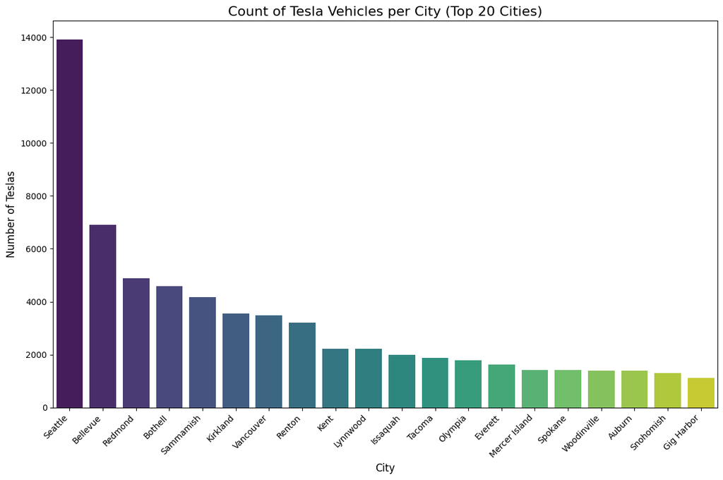

```python
# prompt: create a vertical bar chart with the count of teslas for each city

import matplotlib.pyplot as plt
# Filter for Tesla vehicles
tesla_df = df[df['Make'] == 'TESLA']

# Count the number of Teslas in each city
tesla_city_counts = tesla_df['City'].value_counts().reset_index()
tesla_city_counts.columns = ['City', 'Count']

# Sort by count for better visualization
tesla_city_counts = tesla_city_counts.sort_values(by='Count', ascending=False)

# Take the top N cities to avoid clutter, adjust N as needed
top_n_cities = 20
tesla_city_counts_top = tesla_city_counts.head(top_n_cities)

# Create a vertical bar chart
plt.figure(figsize=(12, 8))
sns.barplot(x='City', y='Count', data=tesla_city_counts_top, palette='viridis')
plt.title(f'Count of Tesla Vehicles per City (Top {top_n_cities} Cities)', fontsize=16)
plt.xlabel('City', fontsize=12)
plt.ylabel('Number of Teslas', fontsize=12)
plt.xticks(rotation=45, ha='right') # Rotate city names for better readability
plt.tight_layout() # Adjust layout to prevent labels overlapping
plt.show()
```

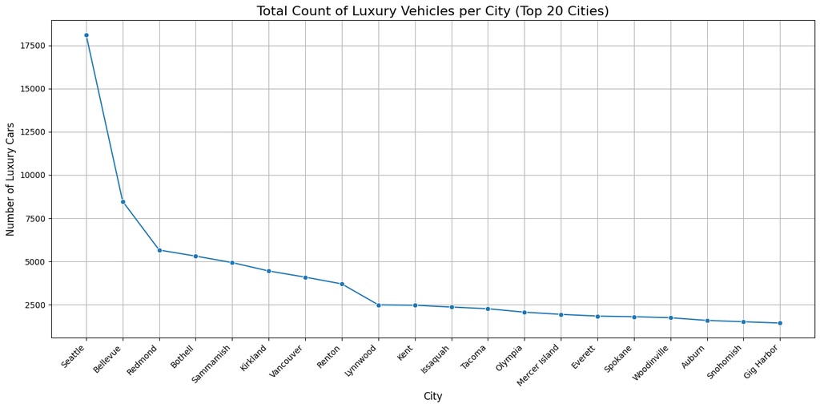

```python
# prompt: create a line chart with the count of luxury cars per city

import matplotlib.pyplot as plt
# Group by city and make, then count the occurrences
car_counts_by_city_make = df.groupby(['City', 'Make']).size().reset_index(name='Count')

# Define a list of common luxury car makes (you might need to adjust this based on your data)
luxury_makes = ['TESLA', 'BMW', 'AUDI', 'MERCEDES-BENZ', 'PORSCHE', 'JAGUAR', 'LEXUS', 'CADILLAC']

# Filter the DataFrame to include only luxury makes
luxury_car_counts = car_counts_by_city_make[car_counts_by_city_make['Make'].isin(luxury_makes)]

# Group by city and sum the counts of luxury cars
luxury_cars_per_city = luxury_car_counts.groupby('City')['Count'].sum().reset_index()

# Sort by count for better visualization
luxury_cars_per_city = luxury_cars_per_city.sort_values(by='Count', ascending=False)

# Take the top N cities to avoid clutter, adjust N as needed
top_n_cities = 20
luxury_cars_per_city_top = luxury_cars_per_city.head(top_n_cities)

# Create a line chart
plt.figure(figsize=(14, 7))
sns.lineplot(x='City', y='Count', data=luxury_cars_per_city_top, marker='o')
plt.title(f'Total Count of Luxury Vehicles per City (Top {top_n_cities} Cities)', fontsize=16)
plt.xlabel('City', fontsize=12)
plt.ylabel('Number of Luxury Cars', fontsize=12)
plt.xticks(rotation=45, ha='right') # Rotate city names for better readability
plt.grid(True) # Add a grid for better readability
plt.tight_layout() # Adjust layout to prevent labels overlapping
plt.show()
```

4. Analysis: Write 1-2 paragraphs discussing:
- Whether your research question can be answered with the available data
- What insights you discovered through your visualizations
- Any unexpected or interesting findings
- Limitations of your analysis
- Suggestions for further investigation

Please create a text cell below this cell to write your analysis.

## Submission Requirements

- Download your notebook as CS110_Project7.ipynb
- Ensure all TODO tasks are completed
- Make sure your code runs without errors
- Include clear comments explaining your work
- Submit the notebook file